# DS 6306 Project 1

William Jones & Christian Orji

2023-02-19

## Project 1 for DS 6306

## # We are tasked with conducting a EDA for the Beers and Breweries Data Set that contains 2410 craft beers and 558 Breweries respectively.

## ## importing the datasets and analyzing the data types

```r
beers = read.csv("/Users/christianorji/Documents/DDS/Beers (1).csv")
breweries = read.csv("/Users/christianorji/Documents/DDS/Breweries (1).csv")
summary(beers)
```

```
##      Name              Beer_ID            ABV               IBU
##  Length:2410        Min.   :   1.0   Min.   :0.00100   Min.   :  4.00
##  Class :character   1st Qu.: 808.2   1st Qu.:0.05000   1st Qu.: 21.00
##  Mode  :character   Median :1453.5   Median :0.05600   Median : 35.00
##                     Mean   :1431.1   Mean   :0.05977   Mean   : 42.71
##                     3rd Qu.:2075.8   3rd Qu.:0.06700   3rd Qu.: 64.00
##                     Max.   :2692.0   Max.   :0.12800   Max.   :138.00
##                                      NA's   :62        NA's   :1005
##    Brewery_id       Style               Ounces
##  Min.   :  1.0   Length:2410        Min.   : 8.40
##  1st Qu.: 94.0   Class :character   1st Qu.:12.00
##  Median :206.0   Mode  :character   Median :12.00
##  Mean   :232.7                      Mean   :13.59
##  3rd Qu.:367.0                      3rd Qu.:16.00
##  Max.   :558.0                      Max.   :32.00
##
```

```r
summary(breweries)
```

```
##     Brew_ID          Name               City              State
##  Min.   :  1.0   Length:558         Length:558         Length:558
##  1st Qu.:140.2   Class :character   Class :character   Class :character
##  Median :279.5   Mode  :character   Mode  :character   Mode  :character
##  Mean   :279.5
##  3rd Qu.:418.8
##  Max.   :558.0
```

```r
unique(beers$Style)
```

```
##   [1] "American Pale Lager"
##   [2] "American Pale Ale (APA)"
##   [3] "American IPA"
##   [4] "American Double / Imperial IPA"
##   [5] "Oatmeal Stout"
##   [6] "American Porter"
##   [7] "Saison / Farmhouse Ale"
##   [8] "Belgian IPA"
##   [9] "Cider"
##  [10] "Baltic Porter"
##  [11] "Tripel"
##  [12] "American Barleywine"
##  [13] "Winter Warmer"
##  [14] "American Stout"
##  [15] "Fruit / Vegetable Beer"
```

[output cut: 85 more lines]

# Question 1

### how many breweries are present in each state?

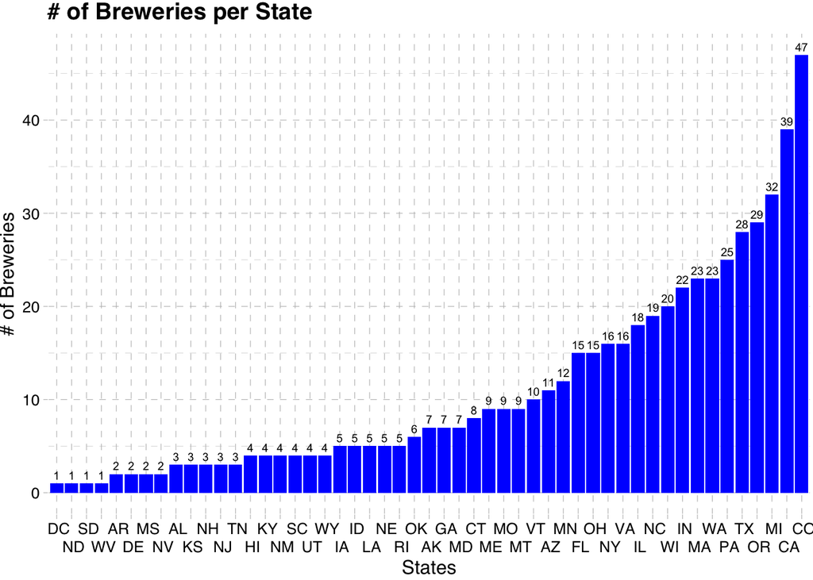

```r
#install.packages("ggthemes")
library(ggplot2)
library(ggthemes)
library(tidyverse)
breweries %>% group_by(State) %>%
  summarise(count = n_distinct(Brew_ID)) %>%
  arrange(count) %>%
  ggplot(aes(x= reorder(State, +count), y = count)) +
  geom_bar(stat="identity", fill ="blue") +
  scale_x_discrete(guide = guide_axis(n.dodge=2)) +
  geom_text(aes(label=count), vjust=-0.5, color="black",
            position = position_dodge(0.9), size=2.5) +
  ylab('# of Breweries') +
  xlab('States') +
  ggtitle('# of Breweries per State') +
  theme_pander()
```

The output is a bar chart showing the number of breweries in each state of the US. The x-axis shows the states and is ordered in ascending order of the number of breweries, while the y-axis shows the count of breweries. The chart is colored in blue and has labels above each bar indicating the count of breweries. Overall, the chart is well-designed and easy to read, and it effectively communicates the information about the distribution of breweries across different states. The use of dodging for the labels and scaling the x-axis helps to prevent overlap and ensure that the chart is easy to read.

# Question 2

### Merging the beer and brewery datasets, both share the Brew/Brewery ID column and contain no missing values so they can be inner joined.

```r
library(dplyr)
#first change one of the datasets column name to match the other
breweries <- breweries %>% rename("Brewery_id"= "Brew_ID")
#Change Name of brewery to avoid duplicate column names
breweries <- breweries %>% rename("Brewery" = "Name")
data <- beers %>% inner_join(breweries, by = "Brewery_id")
#printing of the first 6 rows
head(data) #first 6 rows
```

```
##                  Name Beer_ID   ABV IBU Brewery_id
## 1            Pub Beer    1436 0.050  NA        409
## 2         Devil's Cup    2265 0.066  NA        178
## 3 Rise of the Phoenix    2264 0.071  NA        178
## 4            Sinister    2263 0.090  NA        178
## 5       Sex and Candy    2262 0.075  NA        178
## 6        Black Exodus    2261 0.077  NA        178
##                            Style Ounces                   Brewery City State
## 1            American Pale Lager     12 10 Barrel Brewing Company Bend    OR
## 2        American Pale Ale (APA)     12       18th Street Brewery Gary    IN
## 3                   American IPA     12       18th Street Brewery Gary    IN
## 4 American Double / Imperial IPA     12       18th Street Brewery Gary    IN
## 5                   American IPA     12       18th Street Brewery Gary    IN
## 6                  Oatmeal Stout     12       18th Street Brewery Gary    IN
```

```r
tail(data) # last 6 rows
```

```
##                             Name Beer_ID   ABV IBU Brewery_id
## 2405 Rocky Mountain Oyster Stout    1035 0.075  NA        425
## 2406                   Belgorado     928 0.067  45        425
## 2407               Rail Yard Ale     807 0.052  NA        425
## 2408             B3K Black Lager     620 0.055  NA        425
## 2409         Silverback Pale Ale     145 0.055  40        425
## 2410        Rail Yard Ale (2009)      84 0.052  NA        425
##                         Style Ounces                 Brewery   City State
## 2405           American Stout     12 Wynkoop Brewing Company Denver    CO
## 2406              Belgian IPA     12 Wynkoop Brewing Company Denver    CO
## 2407 American Amber / Red Ale     12 Wynkoop Brewing Company Denver    CO
## 2408              Schwarzbier     12 Wynkoop Brewing Company Denver    CO
## 2409  American Pale Ale (APA)     12 Wynkoop Brewing Company Denver    CO
## 2410 American Amber / Red Ale     12 Wynkoop Brewing Company Denver    CO
```

```r
summary(data)
```

```
##      Name              Beer_ID            ABV               IBU
##  Length:2410        Min.   :   1.0   Min.   :0.00100   Min.   :  4.00
##  Class :character   1st Qu.: 808.2   1st Qu.:0.05000   1st Qu.: 21.00
##  Mode  :character   Median :1453.5   Median :0.05600   Median : 35.00
##                     Mean   :1431.1   Mean   :0.05977   Mean   : 42.71
##                     3rd Qu.:2075.8   3rd Qu.:0.06700   3rd Qu.: 64.00
##                     Max.   :2692.0   Max.   :0.12800   Max.   :138.00
##                                      NA's   :62        NA's   :1005
##    Brewery_id       Style               Ounces        Brewery
##  Min.   :  1.0   Length:2410        Min.   : 8.40   Length:2410
##  1st Qu.: 94.0   Class :character   1st Qu.:12.00   Class :character
##  Median :206.0   Mode  :character   Median :12.00   Mode  :character
##  Mean   :232.7                      Mean   :13.59
##  3rd Qu.:367.0                      3rd Qu.:16.00
##  Max.   :558.0                      Max.   :32.00
##
##      City              State
##  Length:2410        Length:2410
##  Class :character   Class :character
##  Mode  :character   Mode  :character
##
##
##
##
```

```r
#checking string columns for missing cell strings
print(colSums(data == ""))
```

```
##       Name    Beer_ID        ABV        IBU Brewery_id      Style     Ounces
##          0          0         NA         NA          0          5          0
##    Brewery       City      State
##          0          0          0
```

The code first renames the “Brew_ID” column in the breweries dataset to “Brewery_id” to match the corresponding column in the beers dataset. It also renames the “Name” column in the breweries dataset to “Brewery” to avoid duplicate column names.

Then it performs an inner join on the two datasets based on the “Brewery_id” column. The resulting dataset is printed using head(), tail(), and summary() to show the first 6 rows, last 6 rows, and summary statistics of all columns, respectively.

Finally, colSums() is used to check for missing values in string columns. It prints the number of missing values for each string column.